# Project 2

Cassandra Chou

2024-09-21

## Part 1

### part a)

```r
library(tidyverse)
library(tidytuesdayR)

Exp <- function(x, k) {
  exp_val <- 1
  for (i in 1:k) {
    exp_val <- exp_val + x^i/factorial(i)
  }
  exp_val
}

Exp(3, 2)
```

```
## [1] 8.5
```

```r
Exp(3, 100)
```

```
## [1] 20.08554
```

### part b)

```r
sample_mean <- function(x) {
  n <- length(x)
  mean_val <- 0
  for (i in 1:n) {
    mean_val <- mean_val + x[i]
  }

  mean_val/n
}

sample_sd <- function(x) {
  n <- length(x)
  sd_val <- 0
  mean_x <- sample_mean(x)

  for (i in 1:n) {
    sd_val <- sd_val + (x[i] - mean_x)^2
  }

  sd_val <- 1/(n-1) * sd_val
  sqrt(sd_val)
}

sample_mean(c(1, 2, 3, 4, 5))
```

```
## [1] 3
```

```r
sample_sd(c(1, 2, 3, 4, 5))
```

```
## [1] 1.581139
```

```r
sample_mean(c(1, 4, 6, 5, 8, 1))
```

```
## [1] 4.166667
```

```r
sample_sd(c(1, 4, 6, 5, 8, 1))
```

```
## [1] 2.786874
```

### part c)

```r
calculate_CI <- function(x, conf = 0.95) {
  alpha <- 1 - conf
  degrees_freedom <- length(x) - 1
  t_score <- qt(p = alpha / 2, df = degrees_freedom, lower.tail = FALSE)

  mean_x <- mean(x)
  se_x <- sd(x)/sqrt(length(x))
  lower_bound <- mean(x) - t_score*se_x
  upper_bound <- mean(x) + t_score*se_x

  c(lower_bound, upper_bound)
}

# Test
x <- c(1:100)
dat <- data.frame(x = x)
fit <- lm(x ~ 1, dat)

# Calculate a 95% confidence interval
confint(fit, level = 0.95)
```

```
##                2.5 %   97.5 %
## (Intercept) 44.74349 56.25651
```

```r
calculate_CI(x)
```

```
## [1] 44.74349 56.25651
```

```r
# Calculate a 90% confidence interval
confint(fit, level = 0.9)
```

```
##                  5 %     95 %
## (Intercept) 45.68296 55.31704
```

```r
calculate_CI(x, 0.9)
```

```
## [1] 45.68296 55.31704
```

## Part 2

```r
library(here)
if (!file.exists(here("data", "tuesdata_rainfall.RDS"))) {
    tuesdata <- tidytuesdayR::tt_load("2020-01-07")
    rainfall <- tuesdata$rainfall
    temperature <- tuesdata$temperature

    # save the files to RDS objects
    saveRDS(tuesdata$rainfall, file = here("data", "tuesdata_rainfall.RDS"))
    saveRDS(tuesdata$temperature, file = here("data", "tuesdata_temperature.RDS"))
}

rainfall <- readRDS(here("data", "tuesdata_rainfall.RDS"))
temperature <- readRDS(here("data", "tuesdata_temperature.RDS"))

library(tidyverse)
library(dplyr)

glimpse(rainfall)
```

```
## Rows: 179,273
## Columns: 11
## $ station_code <chr> "009151", "009151", "009151", "009151", "009151", "009151…
## $ city_name    <chr> "Perth", "Perth", "Perth", "Perth", "Perth", "Perth", "Pe…
## $ year         <dbl> 1967, 1967, 1967, 1967, 1967, 1967, 1967, 1967, 1967, 196…
## $ month        <chr> "01", "01", "01", "01", "01", "01", "01", "01", "01", "01…
## $ day          <chr> "01", "02", "03", "04", "05", "06", "07", "08", "09", "10…
## $ rainfall     <dbl> NA, NA, NA, NA, NA, NA, NA, NA, NA, NA, NA, NA, NA, NA, N…
## $ period       <dbl> NA, NA, NA, NA, NA, NA, NA, NA, NA, NA, NA, NA, NA, NA, N…
## $ quality      <chr> NA, NA, NA, NA, NA, NA, NA, NA, NA, NA, NA, NA, NA, NA, N…
## $ lat          <dbl> -31.96, -31.96, -31.96, -31.96, -31.96, -31.96, -31.96, -…
## $ long         <dbl> 115.79, 115.79, 115.79, 115.79, 115.79, 115.79, 115.79, 1…
## $ station_name <chr> "Subiaco Wastewater Treatment Plant", "Subiaco Wastewater…
```

```r
glimpse(temperature)
```

```
## Rows: 528,278
## Columns: 5
## $ city_name   <chr> "PERTH", "PERTH", "PERTH", "PERTH", "PERTH", "PERTH", "PER…
## $ date        <date> 1910-01-01, 1910-01-02, 1910-01-03, 1910-01-04, 1910-01-0…
## $ temperature <dbl> 26.7, 27.0, 27.5, 24.0, 24.8, 24.4, 25.3, 28.0, 32.6, 35.9…
## $ temp_type   <chr> "max", "max", "max", "max", "max", "max", "max", "max", "m…
## $ site_name   <chr> "PERTH AIRPORT", "PERTH AIRPORT", "PERTH AIRPORT", "PERTH …
```

```r
df <- rainfall %>% drop_na() %>% mutate(date = ymd(paste(year, month, day, sep = "-"))) %>% select(-month, -day)
df$city_name <- str_to_upper(df$city_name)

df <- inner_join(df, temperature, by = c("city_name",  "date"), relationship =
  "many-to-many")

glimpse(df)
```

```
## Rows: 83,964
## Columns: 13
## $ station_code <chr> "009151", "009151", "009151", "009151", "009151", "009151…
## $ city_name    <chr> "PERTH", "PERTH", "PERTH", "PERTH", "PERTH", "PERTH", "PE…
## $ year         <dbl> 1967, 1967, 1967, 1967, 1967, 1967, 1967, 1967, 1967, 196…
## $ rainfall     <dbl> 2.8, 2.8, 4.8, 4.8, 5.8, 5.8, 16.0, 16.0, 1.0, 1.0, 1.0, …
## $ period       <dbl> 1, 1, 1, 1, 1, 1, 1, 1, 1, 1, 1, 1, 1, 1, 1, 1, 1, 1, 1, …
## $ quality      <chr> "Y", "Y", "Y", "Y", "Y", "Y", "Y", "Y", "Y", "Y", "Y", "Y…
## $ lat          <dbl> -31.96, -31.96, -31.96, -31.96, -31.96, -31.96, -31.96, -…
## $ long         <dbl> 115.79, 115.79, 115.79, 115.79, 115.79, 115.79, 115.79, 1…
## $ station_name <chr> "Subiaco Wastewater Treatment Plant", "Subiaco Wastewater…
## $ date         <date> 1967-07-05, 1967-07-05, 1967-07-06, 1967-07-06, 1967-07-…
## $ temperature  <dbl> 17.8, 8.7, 18.4, 8.0, 17.2, 10.5, 16.1, 4.4, 16.8, 4.1, 2…
## $ temp_type    <chr> "max", "min", "max", "min", "max", "min", "max", "min", "…
## $ site_name    <chr> "PERTH AIRPORT", "PERTH AIRPORT", "PERTH AIRPORT", "PERTH…
```

## Part 3

### part a)

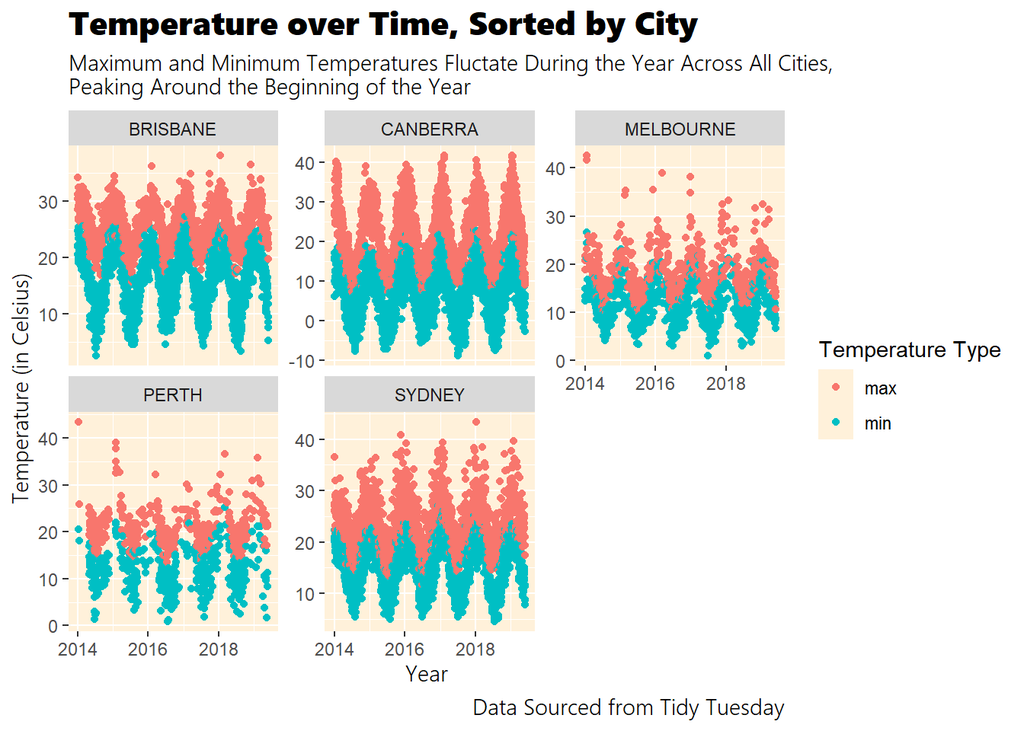

```r
library(ggplot2)
library(extrafont)
ggplot(data = df %>% filter(year >= 2014), aes(x = date, y = temperature)) + geom_point(aes(color = temp_type)) + facet_wrap(~city_name, scales = "free_y") + labs(title = "Temperature over Time, Sorted by City", subtitle = "Maximum and Minimum Temperatures Fluctate During the Year Across All Cities, \nPeaking Around the Beginning of the Year", caption = "Data Sourced from Tidy Tuesday", color = "Temperature Type") + xlab("Year") + ylab("Temperature (in Celsius)") + theme(plot.title = element_text(family = "Segoe UI Black", size = 16), axis.title.x = element_text(family = "Segoe UI Semilight"), axis.title.y = element_text(family = "Segoe UI Semilight"), plot.subtitle = element_text(family = "Segoe UI Semilight"), plot.caption = element_text(family = "Segoe UI Semilight", size = 11), panel.background = element_rect(fill = "#fff1da"))
```

### part b)

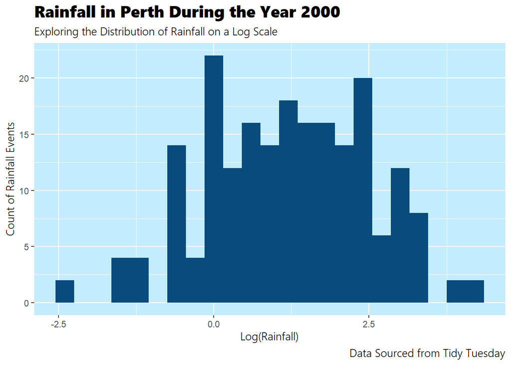

```r
plot_rainfall <- function(city_name, year) {
  city_nm <- str_to_upper(city_name)
  yr <- year

  if (city_nm %in% df$city_name == FALSE) {
    stop("Invalid City!")
  }

  if (yr %in% df$year == FALSE) {
    stop("Invalid Year!")
  }

  df_city_year <- df %>% filter(city_name == city_nm, year == yr)

  if(count(df_city_year) == 0) {
    stop("No combinations of this city/year!")
  }

  plot_title <- paste("Rainfall in", str_to_title(city_nm), "During the Year", yr, sep = " ")
  plot_subtitle <- "Exploring the Distribution of Rainfall on a Log Scale"

  ggplot(df_city_year, aes(log(rainfall))) +
  geom_histogram(binwidth = 0.3, fill = "#094b7c") + xlab("Log(Rainfall)") + ylab("Count of Rainfall Events") + labs(title = plot_title, subtitle = plot_subtitle, caption = "Data Sourced from Tidy Tuesday") +
  theme(plot.title = element_text(family = "Segoe UI Black", size = 16), plot.subtitle = element_text(family = "Segoe UI Semilight"), axis.title.x = element_text(family = "Segoe UI Semilight"), plot.caption = element_text(family = "Segoe UI Semilight", size = 11), axis.title.y = element_text(family = "Segoe UI Semilight"), panel.background = element_rect(fill = "#c3edff"))
}

plot_rainfall("PERTH", 2000)
```

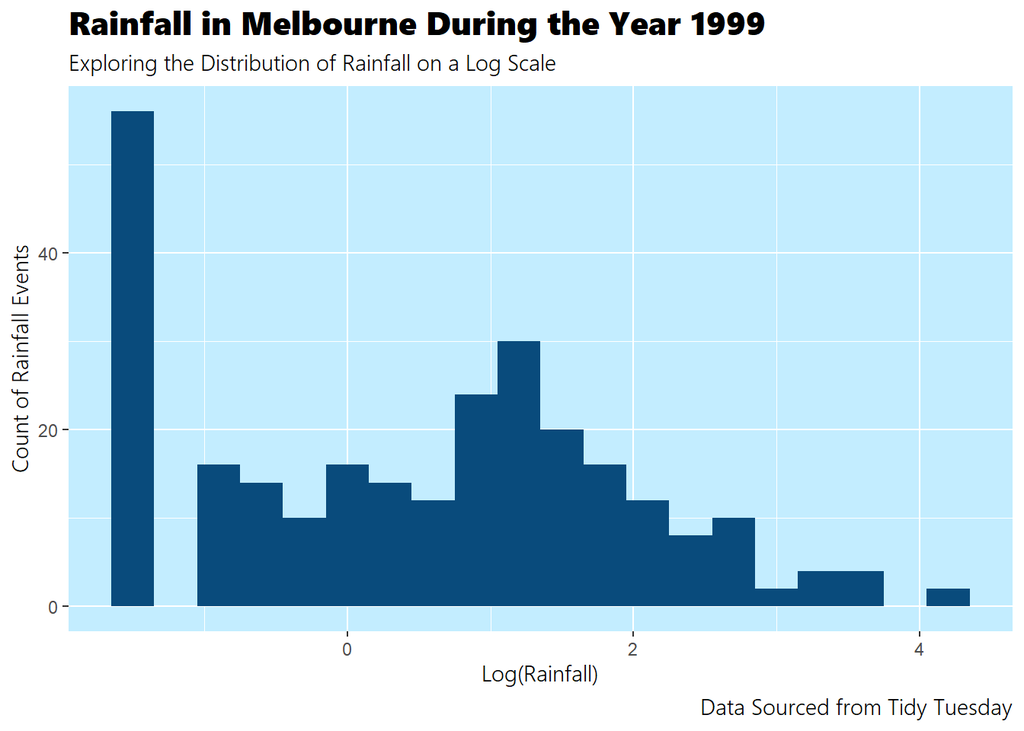

```r
plot_rainfall("MELBOURNE", 1999)
```

Function Design: First, I convert the city name to all captials so that if someone typed “Perth” or “perth” it would still be a valid city name. Then, I check to see if the city and year are valid. If not, I throw an error. Then, I filter the data, and check to see that there is at least one point in this city/year combination. If not, I throw an error saying that this city/year combination is not valid. Then, I create the plot title, and create the plot. I relabeled the axes and the title for clarity and interpretability. I added a bin width in case of city/year combinations with varying dataset sizes, and some color to the plot for aesthetics.

## Part 4

### part a)

```r
rain_df <- df %>% filter(year >= 2014) %>% group_by(city_name, year) %>% drop_na() %>% summarise(mean = sample_mean(rainfall), sd = sample_sd(rainfall), lower_bound = calculate_CI(rainfall)[1], upper_bound = calculate_CI(rainfall)[2])
rain_df
```

```
## # A tibble: 30 × 6
## # Groups:   city_name [5]
##    city_name  year  mean    sd lower_bound upper_bound
##    <chr>     <dbl> <dbl> <dbl>       <dbl>       <dbl>
##  1 BRISBANE   2014  3.84 12.3         2.99        4.69
##  2 BRISBANE   2015  6.17 22.7         4.53        7.82
##  3 BRISBANE   2016  2.09  8.61        1.47        2.72
##  4 BRISBANE   2017  2.72 10.2         1.97        3.47
##  5 BRISBANE   2018  2.47  9.63        1.75        3.19
##  6 BRISBANE   2019  2.10  6.35        1.38        2.82
##  7 CANBERRA   2014  1.57  4.84        1.22        1.92
##  8 CANBERRA   2015  1.51  5.16        1.13        1.89
##  9 CANBERRA   2016  2.15  6.28        1.70        2.61
## 10 CANBERRA   2017  1.33  4.12        1.03        1.63
## # ℹ 20 more rows
```

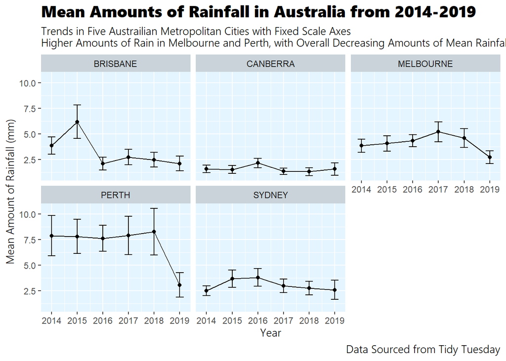

```r
rain_df %>% ggplot(aes(x = year, y = mean)) + geom_point() + geom_line() + geom_errorbar(aes(ymin = lower_bound, ymax = upper_bound), width = 0.3) + facet_wrap(~city_name) + xlab("Year") + ylab("Mean Amount of Rainfall (mm)") + labs(title = "Mean Amounts of Rainfall in Australia from 2014-2019", subtitle = "Trends in Five Austrailian Metropolitan Cities with Fixed Scale Axes\nHigher Amounts of Rain in Melbourne and Perth, with Overall Decreasing Amounts of Mean Rainfall", caption = "Data Sourced from Tidy Tuesday") + theme(plot.title = element_text(family = "Segoe UI Black", size = 16), axis.title.x = element_text(family = "Segoe UI Semilight"), plot.caption = element_text(family = "Segoe UI Semilight", size = 11), axis.title.y = element_text(family = "Segoe UI Semilight"), plot.subtitle = element_text(family = "Segoe UI Semilight"), panel.background = element_rect(fill = "#e5f5ff"), strip.background = element_rect(fill = "#c9d3d9"))
```

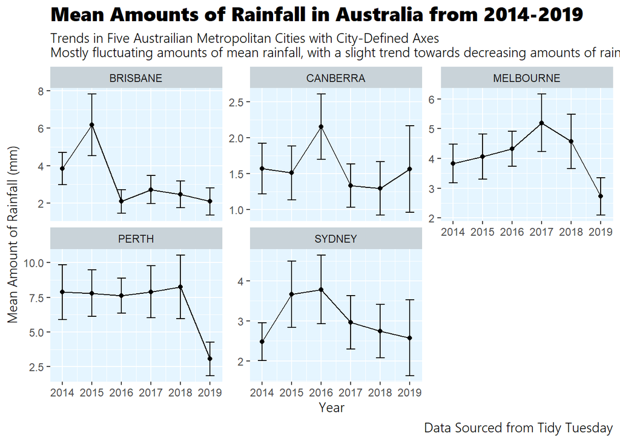

```r
rain_df %>% ggplot(aes(x = year, y = mean)) + geom_point() + geom_line() + geom_errorbar(aes(ymin = lower_bound, ymax = upper_bound), width = 0.3) + facet_wrap(~city_name, scales = "free_y") + xlab("Year") + ylab("Mean Amount of Rainfall (mm)") + labs(title = "Mean Amounts of Rainfall in Australia from 2014-2019", subtitle = "Trends in Five Austrailian Metropolitan Cities with City-Defined Axes\nMostly fluctuating amounts of mean rainfall, with a slight trend towards decreasing amounts of rain", caption = "Data Sourced from Tidy Tuesday") + theme(plot.title = element_text(family = "Segoe UI Black", size = 16), axis.title.x = element_text(family = "Segoe UI Semilight"), plot.subtitle = element_text(family = "Segoe UI Semilight"), plot.caption = element_text(family = "Segoe UI Semilight", size = 11), axis.title.y = element_text(family = "Segoe UI Semilight"), panel.background = element_rect(fill = "#e5f5ff"), strip.background = element_rect(fill = "#c9d3d9"))
```

I plotted two plots with different y-scaling because it is important to see individualized trends in the data by city (city-defined axes), but it is also important to see how rainfall compares between the cities (fixed-scale axes).